# Fatal Car Crashes on 4/20

Barplot

R

Author

Steven Villalon

Published

April 22, 2025

```r
# Load dependencies
library(tidyverse)
library(tidytuesdayR)
```

```r
# Load data
tuesdata <- tidytuesdayR::tt_load('2025-04-22')
names(tuesdata)
```

```
[1] "daily_accidents"     "daily_accidents_420"
```

```r
# Extract tt_data
accidents <- tuesdata$daily_accidents
accidents.420 <- tuesdata$daily_accidents_420

head(accidents)
```

| date | fatalities_count |
| --- | --- |
| 1992-01-01 | 144 |
| 1992-01-02 | 111 |
| 1992-01-07 | 85 |
| 1992-01-12 | 127 |
| 1992-01-03 | 182 |
| 1992-01-17 | 130 |

# Cleaning

```r
# Pull all 4/20 rows
accidents.420[month(accidents.420$date) == 4 & day(accidents.420$date) == 20, ]
```

| date | e420 | fatalities_count |
| --- | --- | --- |
| 1992-04-20 | FALSE | 119 |
| 1992-04-20 | TRUE | 54 |
| 1993-04-20 | FALSE | 79 |
| 1993-04-20 | TRUE | 43 |
| 1994-04-20 | TRUE | 47 |
| 1994-04-20 | FALSE | 63 |
| 1994-04-20 | NA | 1 |
| 1995-04-20 | FALSE | 90 |
| 1995-04-20 | TRUE | 53 |
| 1995-04-20 | NA | 2 |

[output cut: 53 more lines]

```r
# Check for NAs in e420
accidents.420[is.na(accidents.420$e420), ]
```

| date | e420 | fatalities_count |
| --- | --- | --- |
| 1994-04-20 | NA | 1 |
| 1995-04-20 | NA | 2 |
| 1996-04-20 | NA | 1 |
| 1997-04-20 | NA | 2 |
| 2000-04-20 | NA | 1 |
| 2003-04-20 | NA | 1 |
| 2006-04-20 | NA | 1 |
| 2007-04-20 | NA | 1 |
| 2008-04-20 | NA | 1 |
| 2010-04-20 | NA | 2 |

[output cut: 3 more lines]

```r
# Pull all rows where e420 is true
accidents.420[which(accidents.420$e420 == TRUE), ]
```

| date | e420 | fatalities_count |
| --- | --- | --- |
| 1992-04-20 | TRUE | 54 |
| 1993-04-20 | TRUE | 43 |
| 1994-04-20 | TRUE | 47 |
| 1995-04-20 | TRUE | 53 |
| 1996-04-20 | TRUE | 70 |
| 1997-04-20 | TRUE | 52 |
| 1998-04-20 | TRUE | 38 |
| 1999-04-20 | TRUE | 49 |
| 2000-04-20 | TRUE | 65 |
| 2001-04-20 | TRUE | 78 |

[output cut: 15 more lines]

For 4/20 specifically, the accidents.420 dataframe has multiple rows. FALSE is before 4:20pm and TRUE is after. Strange to see NAs in this column.

There are 13 rows where e420 is NA. I will remove because it’s unclear what they mean. In practice, would go to whomever created the dataset and ask why this is happening.

Limiting to e420 = TRUE is misleading because there were other fatalities prior to 4:20pm and I don’t think all the people who “celebrate” 4/20 are waiting until 4pm to get high.

For simplicity, I’m going to focus on the accidents dataset which only includes fatalities by day.

# Exploration

```r
# Summary stats
summary(accidents)
```

```
      date            fatalities_count
 Min.   :1992-01-01   Min.   : 47.0
 1st Qu.:1998-04-01   1st Qu.:121.0
 Median :2004-07-01   Median :142.0
 Mean   :2004-07-01   Mean   :145.1
 3rd Qu.:2010-10-01   3rd Qu.:166.0
 Max.   :2016-12-31   Max.   :299.0
```

```r
print(paste("Standard deviation of fatalities = ", sd(accidents$fatalities_count)))
```

```
[1] "Standard deviation of fatalities =  33.2602881853278"
```

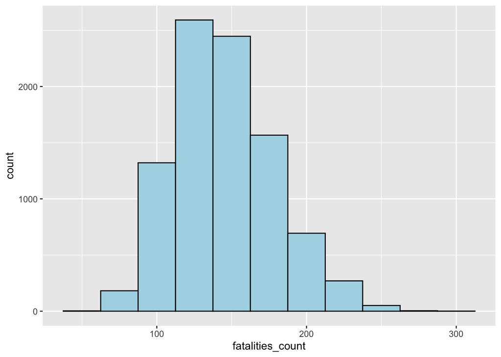

```r
# Histogram of Fatalities
ggplot(accidents, aes(x = fatalities_count)) +
  geom_histogram(binwidth = 25, fill = "lightblue", color = "black")
```

Slightly right skewed with a mean of 145 fatalities per day. Range of 47 to 299 fatalities.

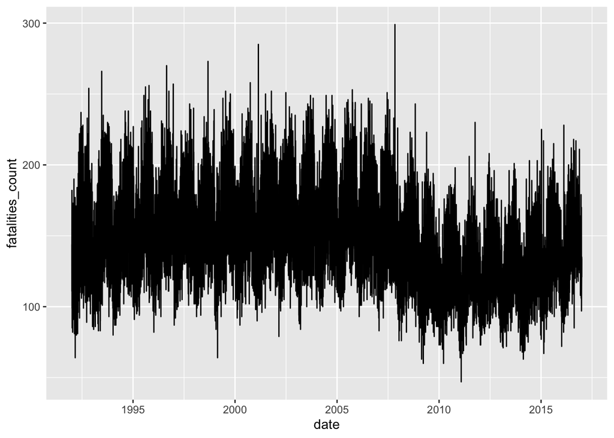

```r
# Time series plot
ggplot(accidents, aes(x = date, y = fatalities_count)) +
  geom_line()
```

```r
# Group by month
accidents$week <- floor_date(accidents$date, "week")
accidents$month <- floor_date(accidents$date, "month")
accidents$year <- floor_date(accidents$date, "year")

head(accidents)
```

| date | fatalities_count | week | month | year |
| --- | --- | --- | --- | --- |
| 1992-01-01 | 144 | 1991-12-29 | 1992-01-01 | 1992-01-01 |
| 1992-01-02 | 111 | 1991-12-29 | 1992-01-01 | 1992-01-01 |
| 1992-01-07 | 85 | 1992-01-05 | 1992-01-01 | 1992-01-01 |
| 1992-01-12 | 127 | 1992-01-12 | 1992-01-01 | 1992-01-01 |
| 1992-01-03 | 182 | 1991-12-29 | 1992-01-01 | 1992-01-01 |
| 1992-01-17 | 130 | 1992-01-12 | 1992-01-01 | 1992-01-01 |

420 is interesting on its own, but I’d like to extend the analysis to look at other “party” holidays to see if fatalities are higher. I can also compare the rate of fatalities to national holidays and non-holiday weekdays and weekends.

Party Holidays:

1. Super Bowl Sunday
2. Mardi Gras
3. St. Patty’s
4. 4/20
5. Cinco de Mayo
6. Halloween
7. Thanksgiving Eve
8. New Year’s Eve

National Holidays:

1. New Year’s Day
2. MLK Day
3. President’s Day
4. Memorial Day
5. Independence Day
6. Labor Day
7. Columbus Day
8. Veterans Day
9. Thanksgiving Day
10. Christmas Day

Let’s bring in a dataset I made using ChatGPT. This dataset has indicators for the holiday. This is not a good practice because I can’t replicate the creation of that dataset. Will look for a more programmatic solution for future projects.

Note that in the code below, I am converting “National Holiday (Observed)” to “National Holiday”. Some National Holidays fall on different dates every year (floating), and sometimes the holiday is observed on a Friday or Monday when the actual day falls on Saturday/Sunday. This is an imperfect solution but makes for a cleaner visualization.

```r
# Load holiday data
holidays <- read_csv("data/holidays.csv",
                     col_types = cols(date = col_date(format = "%m/%d/%y")))

# Join to accidents dataset
accidents_with_holidays <- left_join(accidents, holidays, by = "date")

# Change "National Holiday (Observed)" to "National Holiday"
accidents_with_holidays <- accidents_with_holidays |>
  mutate(day_type = case_when(
    day_type == "National Holiday (Observed)" ~ "National Holiday",
    TRUE ~ day_type  # Keep the rest unchanged
  ))

# Convert day_type and holiday to factors
accidents_with_holidays <- accidents_with_holidays |>
  mutate(
    across(c(day_type, holiday), as.factor),
    day_of_week = factor(day_of_week,
                         levels = c("Sunday", "Monday", "Tuesday", "Wednesday",
                                    "Thursday", "Friday", "Saturday"))
  )

head(accidents_with_holidays)
```

| date | fatalities_count | week | month | year | day_of_week | day_type | holiday |
| --- | --- | --- | --- | --- | --- | --- | --- |
| 1992-01-01 | 144 | 1991-12-29 | 1992-01-01 | 1992-01-01 | Wednesday | National Holiday | New Year's Day |
| 1992-01-02 | 111 | 1991-12-29 | 1992-01-01 | 1992-01-01 | Thursday | Non-Holiday Weekday | NA |
| 1992-01-07 | 85 | 1992-01-05 | 1992-01-01 | 1992-01-01 | Tuesday | Non-Holiday Weekday | NA |
| 1992-01-12 | 127 | 1992-01-12 | 1992-01-01 | 1992-01-01 | Sunday | Non-Holiday Weekend | NA |
| 1992-01-03 | 182 | 1991-12-29 | 1992-01-01 | 1992-01-01 | Friday | Non-Holiday Weekday | NA |
| 1992-01-17 | 130 | 1992-01-12 | 1992-01-01 | 1992-01-01 | Friday | Non-Holiday Weekday | NA |

```r
# Summary table of Day Type
avg_fatalities_day_type <- accidents_with_holidays |>
  group_by(day_type) |>
  summarize(avg_fatalities = round(mean(fatalities_count),1)) |>
  arrange(desc(avg_fatalities))
avg_fatalities_day_type
```

| day_type | avg_fatalities |
| --- | --- |
| Non-Holiday Weekend | 165.8 |
| Party Holiday | 141.8 |
| National Holiday | 139.9 |
| Non-Holiday Weekday | 136.9 |

```r
# Summary table of Holiday
avg_fatalities_holiday <- accidents_with_holidays |>
  group_by(holiday) |>
  summarize(
        day_type = first(day_type),
        avg_fatalities = round(mean(fatalities_count), 1)
  ) |>
  na.omit(holiday) |> # removes non-holiday weekdays/weekends
  arrange(desc(avg_fatalities))
avg_fatalities_holiday
```

| holiday | day_type | avg_fatalities |
| --- | --- | --- |
| Independence Day | National Holiday | 176.0 |
| Thanksgiving Eve | Party Holiday | 172.4 |
| Halloween | Party Holiday | 168.6 |
| New Year's Day | National Holiday | 156.7 |
| Veterans Day | National Holiday | 151.9 |
| Labor Day | National Holiday | 142.5 |
| Memorial Day | National Holiday | 141.2 |
| Cinco de Mayo | Party Holiday | 140.4 |
| Thanksgiving Day | National Holiday | 140.2 |
| 420 | Party Holiday | 139.3 |

[output cut: 8 more lines]

# Visualization

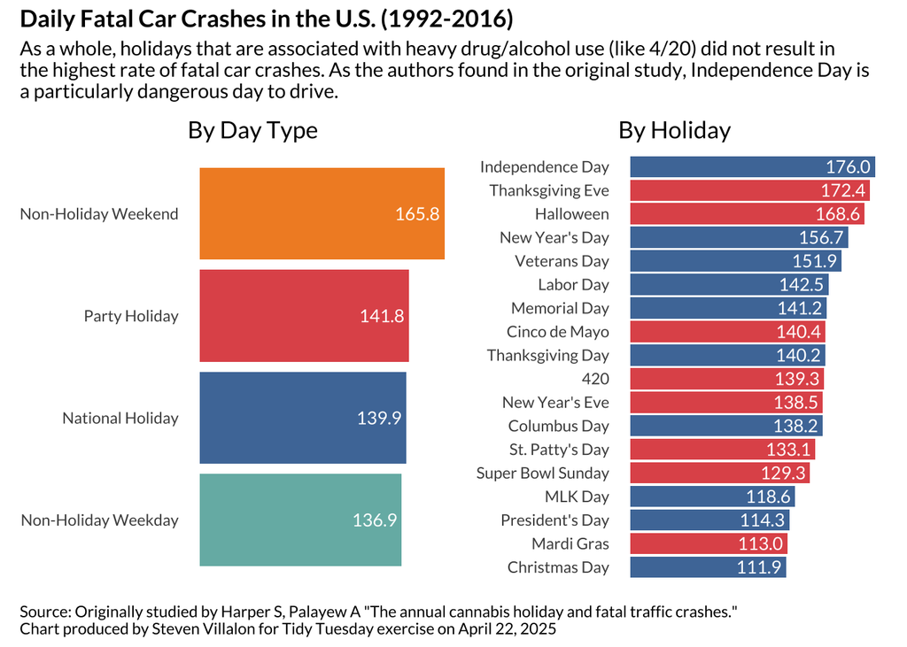

```r
# Create side by side Bar Plot
library(patchwork)
library(showtext)

# Load font
family <- "Lato"
font_add(family = family,
         regular = "Lato-Regular.ttf",
         bold = "Lato-Bold.ttf")
showtext_auto()
showtext_opts(dpi = 300)

# Colors
my_colors <- c(
  "Non-Holiday Weekday" = "#76B7B2",
  "Non-Holiday Weekend" = "#F28E2B",
  "National Holiday"     = "#4E79A7",
  "Party Holiday"        = "#E15759"
)

# Reorder factor levels in descending order
avg_fatalities_day_type <- avg_fatalities_day_type |>
  mutate(day_type = reorder(day_type, avg_fatalities))

avg_fatalities_holiday <- avg_fatalities_holiday |>
  mutate(holiday = reorder(holiday, avg_fatalities))

# Plot 1
p1 <- ggplot(avg_fatalities_day_type, aes(x = avg_fatalities, y = day_type, fill = day_type)) +
  geom_bar(stat = "identity") +
  geom_text(aes(label = sprintf("%.1f", avg_fatalities)), hjust = 1.1, color = "white", size = 3.5, family = family) +
  labs(title = "By Day Type", x = NULL, y = NULL) +
  scale_fill_manual(values = my_colors) +
  theme_minimal() +
  theme(
    legend.position = "none",
    panel.grid = element_blank(),
    axis.text.x = element_blank(),
    axis.ticks.x = element_blank(),
    text = element_text(family = family)
  )

# Plot 2
p2 <- ggplot(avg_fatalities_holiday, aes(x = avg_fatalities, y = holiday, fill = day_type)) +
  geom_bar(stat = "identity") +
  geom_text(aes(label = sprintf("%.1f", avg_fatalities)), hjust = 1.1, color = "white", size = 3.5, family = family) +
  labs(title = "By Holiday", x = NULL, y = NULL) +
  scale_fill_manual(values = my_colors) +
  theme_minimal() +
  theme(
    legend.position = "none",
    panel.grid = element_blank(),
    axis.text.x = element_blank(),
    axis.ticks.x = element_blank(),
    text = element_text(family = family)
  )

# Plot Title, Subtitle, and Caption
plot_title <- plot_annotation(
  title = "Daily Fatal Car Crashes in the U.S. (1992-2016)",
  subtitle = "As a whole, holidays that are associated with heavy drug/alcohol use (like 4/20) did not result in \nthe highest rate of fatal car crashes. As the authors found in the original study, Independence Day is \na particularly dangerous day to drive.",
  caption = "Source: Originally studied by Harper S, Palayew A \"The annual cannabis holiday and fatal traffic crashes.\"\nChart produced by Steven Villalon for Tidy Tuesday exercise on April 22, 2025",
  theme = theme(text = element_text(family = family),
                plot.caption.position = "plot",
                plot.caption = element_text(hjust = 0),
                plot.title = element_text(face = "bold"))
)

p1 + p2 + plot_title
```

Back to top